# Classification Case Study: Kiva Loans

Stephen W. Thomas

# 1 Introduction

Kiva Microfunds is a non-profit that allows people to lend money to low0income entrepreneurs and students around the world. Started in 2005, Kiva has crowd-funded millions of loans with a repayment rate of 98% to 99%.

In additional to traditional demographic data, Kiva includes personal stories on each loan seaker because they want their leanders to connect with their entreprenuers on a human level.

In this case study, we will build a prediction model (in particular, a decision tree classifier) to predict who will pay back loans, and who will default. A key question we want to ask is: does adding text (i.e., the personal stories) to the model increase its prediction power?

# 2 Discussion Questions

At the end of this case study, we will have a group discussion around the following questions:

- Does text data help in predicting which borrowers will default?
- Which words are most biased towards defaulting? Is this expected?
- According to the decision tree models, what variables predict a default?
- As a decision maker, would you recommend the use of textual data in your prediction algorithms?

# 3 Descriptive Statistics

It’s always a good idea to get familiar with the data by understanding the variables, their values, etc.

First, how many variables are there, and what are their names?

```
## [1] 8
```

```
## [1] "status"      "sector"      "en"          "country"     "gender"
## [6] "loan_amount" "nonpayment"  "id"
```

Most the names of the variables are self-describing. The `en` variable is the text variable, i.e., the personal story of the loan seeker.

How many rows (records) are there?

```
## [1] 7988
```

Let’s look at some basic summary statistics on the numeric columns columns:

```
##        status             sector                   country     gender
##  defaulted:3411   Food       :2432   Dominican Republic:2018   F:5986
##  paid     :4577   Retail     :1895   Ecuador           :2702   M:2002
##                   Agriculture:1104   Kenya             :3268
##                   Clothing   :1080
##                   Services   : 822
##                   Health     : 156
##                   (Other)    : 499
##   loan_amount       nonpayment         id
##  Min.   :  25.0   lender :3403   Min.   :   1
##  1st Qu.: 375.0   partner:4585   1st Qu.:1998
##  Median : 600.0                  Median :3994
##  Mean   : 708.8                  Mean   :3994
##  3rd Qu.: 925.0                  3rd Qu.:5991
##  Max.   :5000.0                  Max.   :7988
##
```

Let’s look at a few of the records in full. Let’s select four at random, two that have `paid`, and two that have `defaulted`.

| status | sector | country | gender | loan_amount | nonpayment | en |
| --- | --- | --- | --- | --- | --- | --- |
| defaulted | Agriculture | Kenya | M | 500 | lender | This description is written by Rowland Amulyoto, a staff member of Village Enterprise Fund who will be representing this business. Robert, 40, is married and has 6 children. In addition to his family … |
| defaulted | Agriculture | Kenya | F | 900 | lender | Evelyn is 40 years old and married with 3 kids. She is in the Karura Hope women group and her life has been changed by the first KIVA loan she received last year which she is completing this quarter. … |
| paid | Clothing | Kenya | M | 150 | partner | I am a father of 3, aged 34 years. I also take care of my parents and nephews. I sell second-hand men’s clothing. I wish to earn more money through diversifying my business. |
| paid | Food | Dominican Republic | F | 800 | partner | Alina Sosa Sosa is a single mother of four: Emiar de Sanchez (15), Adyes (14), Roselin de Sanchez (13), Samira de Sanchez (11). With this loan she is hoping to open up a chicken farm and restaurant. H… |

## 3.1 Variable: sector

Below is a cross tabulation for the variables sector (rows) and status (columns), along with sums of each row and column.

```
##                 status
## sector           defaulted paid  Sum
##   Agriculture          769  335 1104
##   Arts                  81   63  144
##   Clothing             386  694 1080
##   Construction          42   47   89
##   Education              5   13   18
##   Entertainment          2    2    4
##   Food                 927 1505 2432
##   Health                33  123  156
##   Housing               23   12   35
##   Manufacturing         52   92  144
##   Personal Use           0    3    3
##   Retail               718 1177 1895
##   Services             337  485  822
##   Transportation        31   17   48
##   Wholesale              5    9   14
##   Sum                 3411 4577 7988
```

Below is a graphical representation of the same tabulation, color-coded by those who paid (blue, bottom) and those who did not (orange, top):

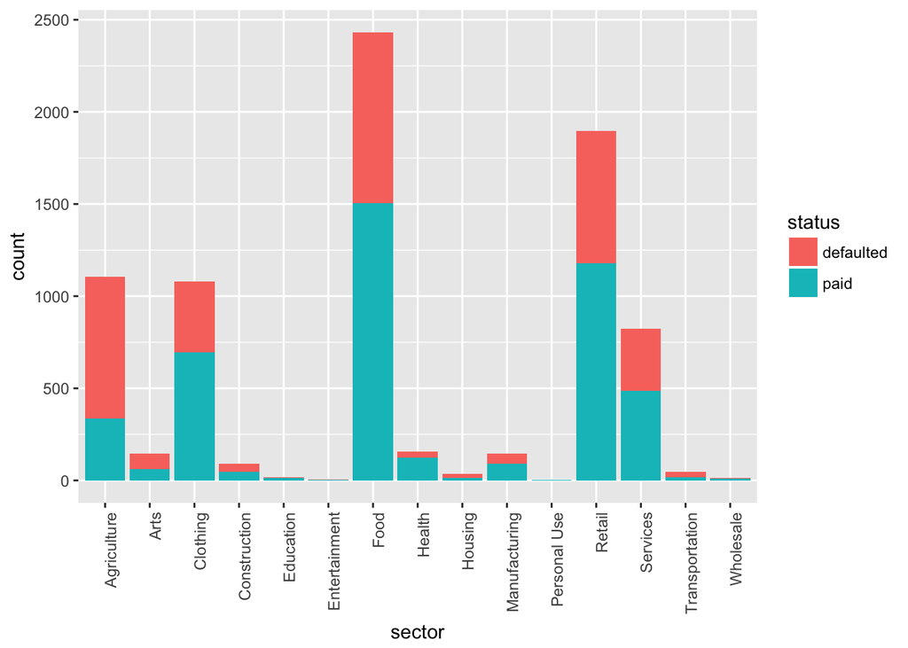

## 3.2 Variable: country

Let’s do the same for the `country` variable: cross tabulation table, and a graphical representation.

```
##                     status
## country              defaulted paid  Sum
##   Dominican Republic       485 1533 2018
##   Ecuador                  739 1963 2702
##   Kenya                   2187 1081 3268
##   Sum                     3411 4577 7988
```

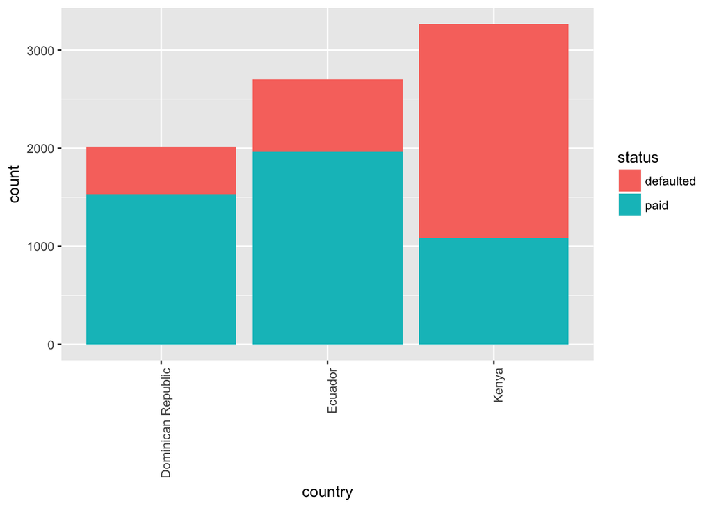

## 3.3 Variable: gender

```
##       status
## gender defaulted paid  Sum
##    F        2541 3445 5986
##    M         870 1132 2002
##    Sum      3411 4577 7988
```

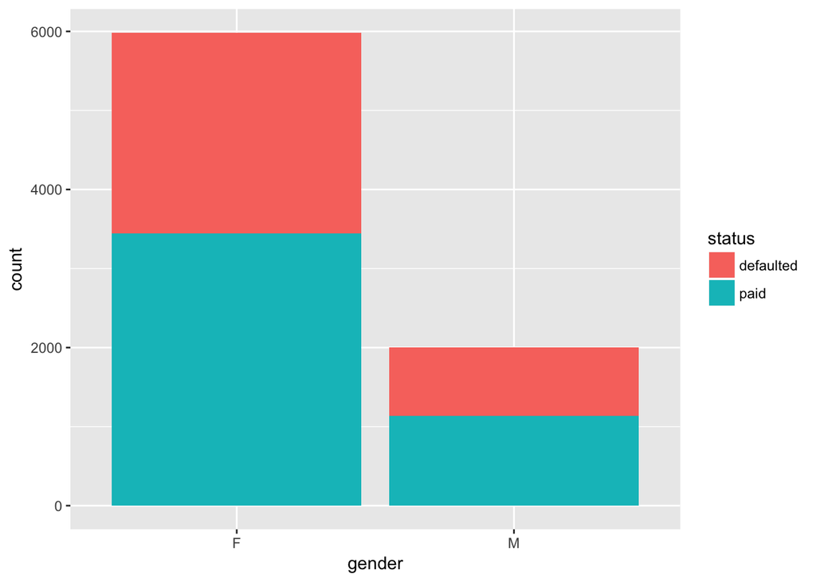

## 3.4 Variable: nonpayment

```
##           status
## nonpayment defaulted paid  Sum
##    lender       2887  516 3403
##    partner       524 4061 4585
##    Sum          3411 4577 7988
```

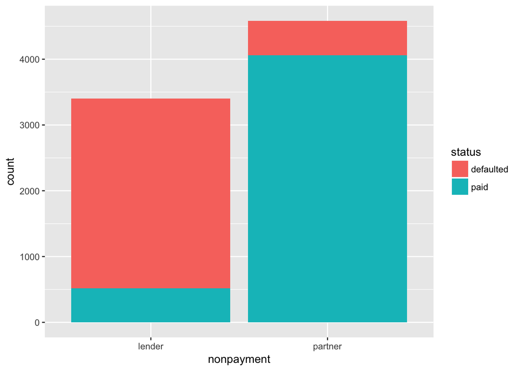

## 3.5 Variable: loan_amount

Since the `loan_amount` variable is numeric, we can look at a density plot.

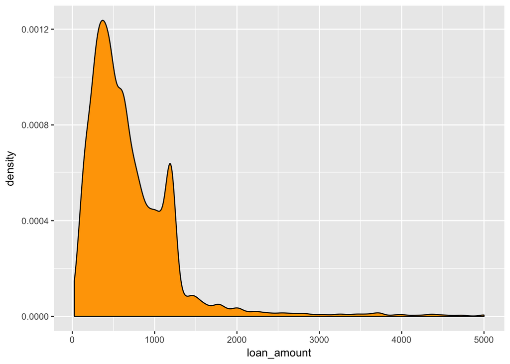

We can show a separate density for `status=defaulted` and `status=paid`.

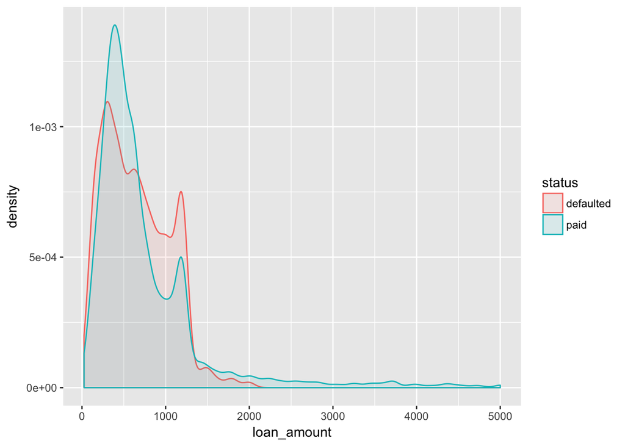

And we can even show a “filled” density plot:

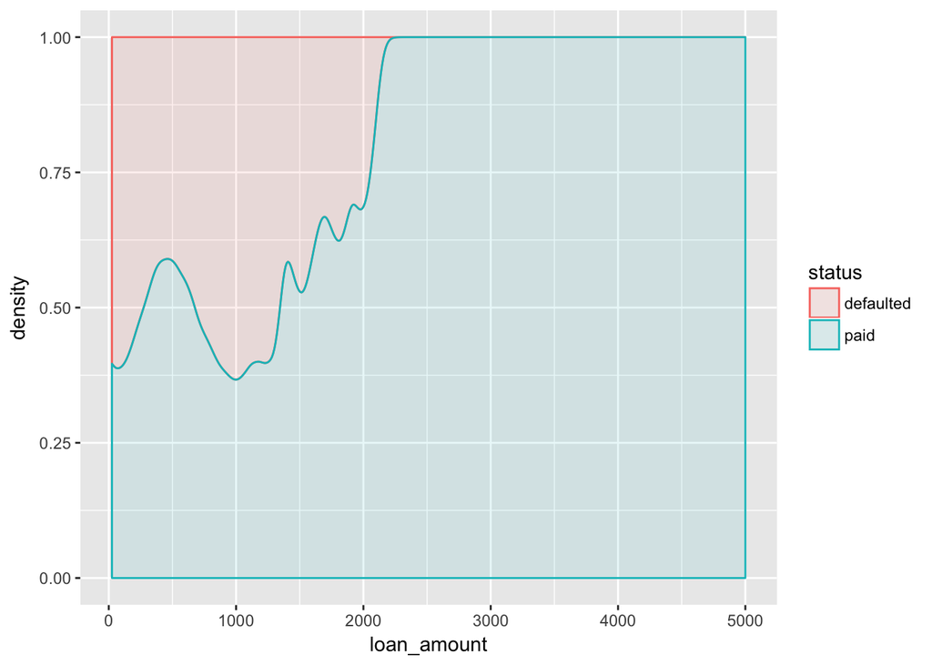

```
##                status
## loan_amount.cut defaulted paid  Sum
##   (0,300]             906  930 1836
##   (300,600]           899 1717 2616
##   (600,900]           694  792 1486
##   (900,1.5e+03]       860  776 1636
##   Sum                3359 4215 7574
```

## 3.6 Variable: en

The `en` variable is raw English text, and there’s lots of ways we can look at it.

First, let’s look at the length (number of characters/letters).

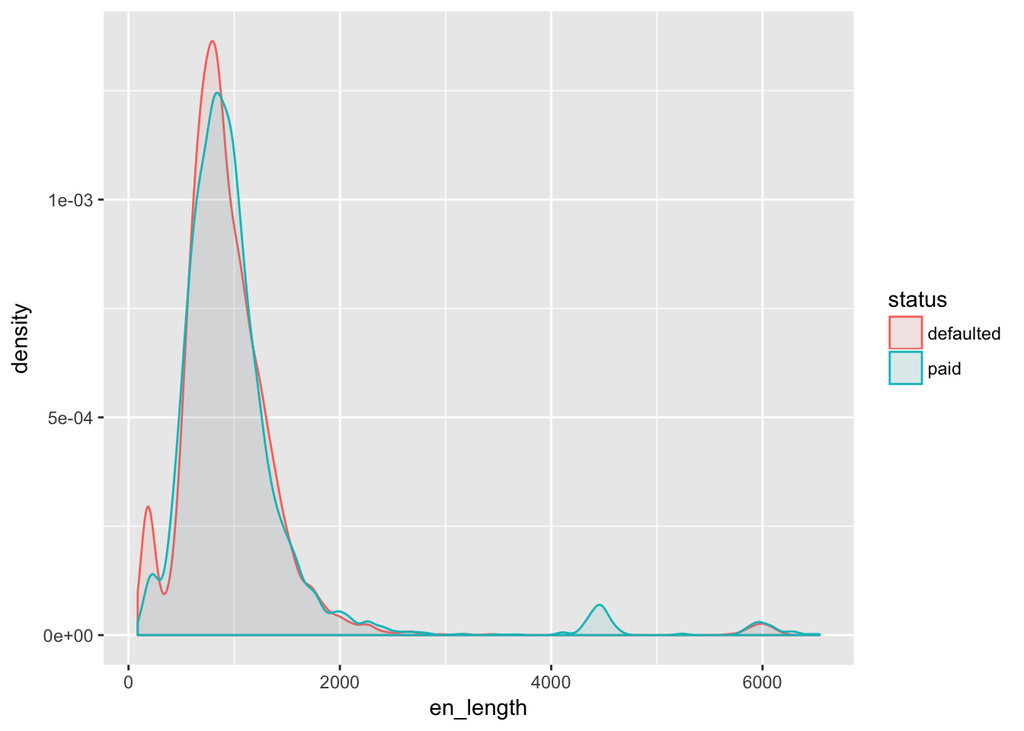

Let’s look at the top (i.e, most frequent) words.

```
## # A tibble: 20,004 × 3
##        word count        freq
##       <chr> <int>       <dbl>
## 1  children  8634 0.015161706
## 2    school  5124 0.008997982
## 3       buy  4963 0.008715259
## 4     sells  3957 0.006948676
## 5    family  3764 0.006609759
## 6  products  3289 0.005775637
## 7   husband  3273 0.005747540
## 8    income  3203 0.005624617
## 9   married  3081 0.005410379
## 10  selling  2979 0.005231263
## # ... with 19,994 more rows
```

Now, let’s see which words are more biased towards being `paid` or `defaulted`, using the log odds ratio metric.

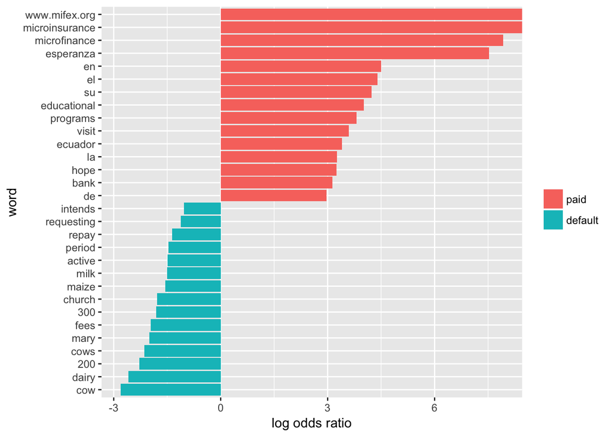

Let’s look at a table of the same data above, first focusing on the words that are biased towards `paid`:

```
## # A tibble: 209 × 5
##              word defaulted  paid total log_ratio
##             <chr>     <dbl> <dbl> <dbl>     <dbl>
## 1  microinsurance         0   603   603       Inf
## 2   www.mifex.org         0   601   601       Inf
## 3    microfinance         3   726   729  7.918863
## 4       esperanza         6  1112  1118  7.533979
## 5              en        24   544   568  4.502500
## 6              el        30   633   663  4.399171
## 7              su        41   769   810  4.229288
## 8     educational        38   613   651  4.011816
## 9        programs        55   771   826  3.809227
## 10          visit        62   746   808  3.588836
## # ... with 199 more rows
```

And those that are biased towards `default`:

```
## # A tibble: 209 × 5
##      word defaulted  paid total log_ratio
##     <chr>     <dbl> <dbl> <dbl>     <dbl>
## 1     cow       455    65   520 -2.807355
## 2   dairy       914   152  1066 -2.588123
## 3     200       454    93   547 -2.287390
## 4    cows       414    94   508 -2.138898
## 5    mary       412   103   515 -2.000000
## 6    fees       687   176   863 -1.964735
## 7     300       394   112   506 -1.814697
## 8  church       561   163   724 -1.783129
## 9   maize       480   163   643 -1.558162
## 10   milk       767   270  1037 -1.506267
## # ... with 199 more rows
```

## 3.7 LDA Topics

We used a techinque called Latent Dirichlet Allocation (LDA) to automatically uncover the topics from the documents. We told LDA to discover the `12` most important topics in the documents; LDA will also tell us which topics are in which documents.

First, let’s look at the top terms (words) in each discovered topic.

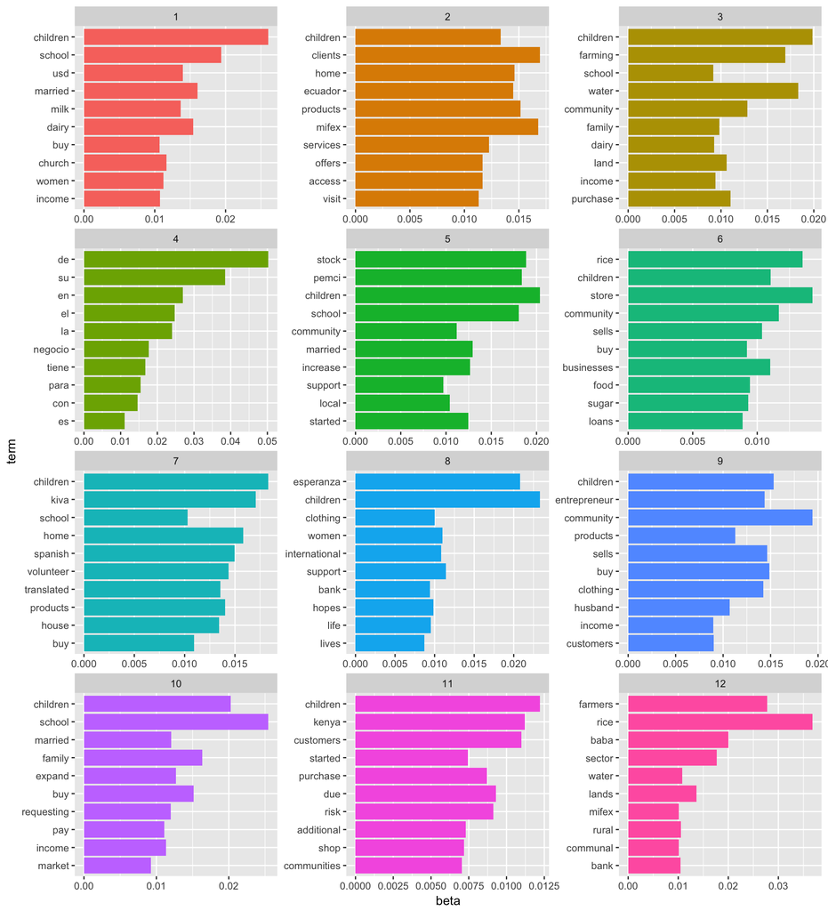

Next, let’s look at how many documents have each topic.

```
## Source: local data frame [12 x 4]
## Groups: topic [12]
##
##    topic defaulted  paid total
##    <int>     <int> <int> <int>
## 1      1      1041   424  1465
## 2      2       279  1189  1468
## 3      3       581   388   969
## 4      4        23   153   176
## 5      5       430   676  1106
## 6      6       343  1007  1350
## 7      7       724  1050  1774
## 8      8       179  1038  1217
## 9      9       660  1059  1719
## 10    10      1332   617  1949
## 11    11       718   616  1334
## 12    12       131   254   385
```

# 4 Building a Classifier Model

Now that we have explored the data, it’s time to dive deeper. Which variable(s) are the biggest predictors of status? This is where classifier models shine. They can tell us exactly how all the variables relate to each other, and which are most important.

A decision tree is a popular classifier model in analytics. Here, the decision tree is automatically created by a machine learning algorithm as it learns simple decision rules from the data. These automatically-learned rules can then be used to both understand the variables and to predict future data. A big advantage of decision trees over other classifier models is that they are relatively simple for humans to understand and interpret.

A decision tree consists of nodes. Each node splits the data according to a rule. A rule is based on a variable in the data. For example, a rule might be “Age greater than 30.” In this case, the node splits the data by the age variable; those passengers that satisfy the rule (i.e., are greater than 30) follow the left path out of the node; the rest follow the right path out of the node. In this way, paths from the root node down to leaf nodes are created, describing the fate of certain types of passengers.

A decision tree path always starts with a root node (node number 1), which contains the most important splitting rule. Each subsequent node contains the next most important rule. After the decision tree is automatically created by the machine learning algorithm, one can use the decision tree to classify an individual by simply following a path: start at the root node and apply each rule to follow the appropriate path until you hit an end.

When creating a decision tree from data, the analyst can specify the number of nodes for the machine learning algorithm to create. More nodes leads to a more accurate model, at the cost of a more complicated and harder-to-interpret model. Likewise, fewer nodes usually leads to a less accurate model, but the model is easier to understand and interpret.

# 5 A model without the text

First, as a baseline, let’s train a decision tree classifier model without using any of the text or topics. Here is a graphical depiction of the model after it has been trained:

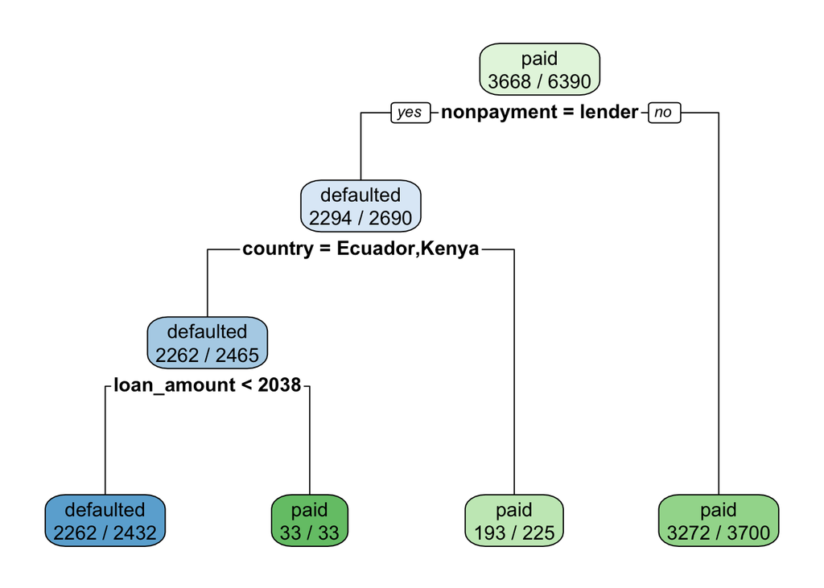

Let’s look at the confusion matrix.

```
##            predicted
## actual      defaulted paid
##   defaulted        50   39
##   paid             24  120
```

Let’s check the accuracy and other metrics of the classifier on the testing data.

```
## [1] "Accuracy:    0.730"
```

```
## [1] "Precision:   0.676"
```

```
## [1] "Recall:      0.562"
```

```
## [1] "F1 Score:    0.613"
```

```
## [1] "Sensitivity: 0.562"
```

```
## [1] "Specificity: 0.755"
```

# 6 A model with the text

Now, let’s build the same decision tree classifier model as before, except now, let’s include the LDA topics, built from the text.

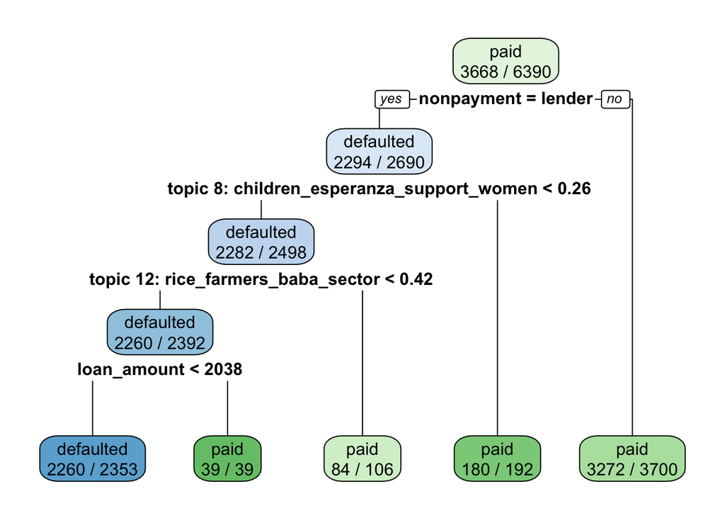

Confusion matrix:

```
##            predicted
## actual      defaulted paid
##   defaulted       573  106
##   paid             35  556
```

Metrics:

```
## [1] "Accuracy:    0.889"
```

```
## [1] "Precision:   0.942"
```

```
## [1] "Recall:      0.844"
```

```
## [1] "F1 Score:    0.890"
```

```
## [1] "Sensitivity: 0.844"
```

```
## [1] "Specificity: 0.840"
```